# Data Science for Public Policy

Final Project

Author

J Lei, Kieran Connolly, Parker Lazear

# Education and Broadband Connectivity in West Virginia

## Background and Literature Review

Background

Many purport that education is the “great equalizer” and through education, students will be able to overcome socio-economic barriers within society.

Even if true equity could be found for students inside the classroom, the idea that the world around the student does not impact the school day is at best naive. When the COVID-19 pandemic hit, schools moved to remote learning, the world outside the classroom had a greater impact and many realized how far from equity we were. Internet accessibility shone through as a huge divide for students. As the country becomes more digitized, students without reliable strong internet in their homes are put at an extremely unfair disadvantage when it comes to access to education.

While there is a large push for research in this area currently, so many of the impacts are new and the data is relatively incomplete. In the 2023 recommendations from the FCC on digital learning, nearly all of the data provided is from qualitative interviews and leaves room for large errors and differences in experiences (Digital Empowerment and Inclusion Working Group of the Communications Equity and Diversity Council. Federal Communications Commission, 2023). Most of the quantitative research that has been done on this subject was done before the pandemic, and not only has internet connectivity and internet learning changed vastly since then, but we have also learned, importantly, that asking “Do you have internet in your home?” does not capture differences in broadband connectivity versus unreliable dial-up.

These limitations cause large errors in earlier data, like a report done by the Milken Institute that tries to find the exact models we are trying to show. Beyond that, the Milken report uses incomplete data with high degrees of missingness (Lee, 2017). A series of studies at Rutgers found that of the 84 percent of low-income families who do have wifi access, 56 percent have extremely slow internet and 18 percent have unreliable internet (Sullivan, 2021). Our report helps begin to fill a gap in the education policy space being able to come closer to an actual answer to the question of how internet connectivity impacts education.

Approach

As such, our main motivating question was whether we could discern patterns that could indicate the impact of internet access on educational attainment. To produce the least confounding results, we have chosen to specify West Virginia as our area of interest. We chose this state for its lack of broadband access paired with its high percentage of rural areas and lower geographic mobility. While other states also suffer from a lack of broadband, it is often a result of economic status, which also impacts educational attainment and success.

To begin to answer this question, we first did an exploratory data analysis to generally understand the patterns in the data. We then use geospatial analysis to map broadband access and different educational levels in West Virginia. Then, we created a linear regression supervised machine learning model that takes into account income as well as educational attainment and population size of a census tract to predict broadband access. We then provided geospatial maps of the testing data predictions as well as predictions for if the model was used on all the data in West Virginia.

Our analysis attempts to use educational attainment as a key ingredient in predicting broadband access. This is relevant to policy research in two ways. First, being able to demonstrate a connection between broadband and educational levels is the first step towards determining how broadband access could actually have an impact on student learning. Secondly, given the shortcomings of current data, being able to predict the availability of broadband internet will be a practical tool for policymakers in many fields.

Sources Cited

Digital Empowerment and Inclusion Working Group of the Communications Equity and Diversity Council. Federal Communications Commission. (2023). Connecting Opportunity Communities to Broadband During the COVID-19 Pandemic: Lessons Learned and Recommendations. https://www.fcc.gov/sites/default/files/cedc-digital-empowerment-inclusion-wg-broadband-access-report-06152023.pdf

Lee, Joe. (2017). Internet Usage Effect on Educational Attainment: Evidence of Benefits. Milken Institute.https://milkeninstitute.org/sites/default/files/reports-pdf/Internet-Usage-and-Educational-Attainment-FINAL.pdf

Sullivan, E. (2021, July 23). Millions of Students With Home Internet Access Still Can’t Get Online. EdSurge. https://www.edsurge.com/news/2021-07-23-millions-of-students-with-home-internet-access-still-can-t-get-online.

## Library of Packages

```r
library(tidyverse)
library(dplyr)
library(readr)
library(sf)
library(recipes)
library(tidymodels)
library(broom)
library(patchwork)
library(ggplot2)
library(tidyclust)
library(Rfast)
library(workflows)
library(sf)
library(gganimate)
library(patchwork)
library(yardstick)
```

### I) Income.csv

https://data.census.gov/table/ACSST1Y2018.S1903?q=West%20Virginia%20income&g=040XX00US54$0500000,54$1400000&y=2018 The dataset was obtained from data.census.gov, which provides detailed survey information at the census tract level from the American Community Survey. Specifically, the variable of interest is median income in the past 12 months, designated by the code S1903, and is sourced from the ACS 5-Year data for 2018 in West Virginia. To extract this dataset, five specific filters were applied: 1)Under the “Geography” filter, “West Virginia” was selected. 2)All counties within West Virginia were included. 3)All census tracts within West Virginia were chosen. 4)The year 2018 was specified. 5)Under the “Topics” filter, the focus was set on “Income and Poverty,” specifically targeting the subcategory “Income (Households, Families, Individuals).” After applying the initial filters, we selected “2018: ACS 5-Year Estimate Subject Tables” from the view All 2 Products options. This was followed by clicking on the “Download Table” button to retrieve the data. The specific table vintage that was chosen corresponds to the column labeled “2018” and the row titled “ACS 5-Year Estimate Subject Tables.” Upon completing the download of the dataset from the “2018: ACS 5-Year Estimate Subject Tables,” we proceeded to modify the data for analysis. The first step in the modification process was to remove the initial row, which contained only the codes corresponding to each variable. Following this, we refined the dataset to include only six specific columns, which are critical for our analysis:

1)Geoid (Geography): This column provides the geographic identifier for each area. 2)Area_Name (Geographic Area Name): This column contains the names of the geographic areas. 3)Households (Estimate!!Number!!HOUSEHOLD INCOME BY RACE AND HISPANIC OR LATINO ORIGIN OF HOUSEHOLDER!!Households): This column includes estimates of the number of households. 4)Household MOE (Margin of Error!!Number MOE!!HOUSEHOLD INCOME BY RACE AND HISPANIC OR LATINO ORIGIN OF HOUSEHOLDER!!Households): This column provides the margin of error associated with the household estimates. 5)Income (Estimate!!Median income (dollars)!!HOUSEHOLD INCOME BY RACE AND HISPANIC OR LATINO ORIGIN OF HOUSEHOLDER!!Households): This column shows the median household income estimates. 6)Income MOE (Margin of Error!!Median income (dollars) MOE!!HOUSEHOLD INCOME BY RACE AND HISPANIC OR LATINO ORIGIN OF HOUSEHOLDER!!Households): This column presents the margin of error for the median income estimates.

### II) Census_data.csv

https://data.census.gov/table?q=West%20Virginia%20internet&g=040XX00US54$0500000,54$1400000 The dataset, also sourced from data.census.gov, focuses on the variable “Types of Computers and Internet Subscription,” coded as S2801. The process for obtaining this dataset mirrors the earlier approach in terms of applying filters for geography and years. After applying the initial filters, we selected the “2018: ACS 5-Year Estimate Subject Tables” from the view All 2 Products options. This was followed by clicking on the “Download Table” button to retrieve the data. The specific table vintage that was chosen corresponds to the column labeled “2018” and the row titled “ACS 5-Year Estimate Subject Tables.”

Upon completing the download of the dataset from the “2018: ACS 5-Year Estimate Subject Tables,” we proceeded to modify the data for analysis. The first step in the modification process was to remove the initial row, which contained only the codes corresponding to each variable. Following this, we refined the dataset to include only five specific columns, which are critical for our analysis:

1)Geoid (Geography) 2) Geographic Area Name 3) Total Households Estimate (Estimate!!Total!!Total households) 4) Broadband of any type, estimate (Estimate!!Total!!TYPE OF INTERNET SUBSCRIPTIONS!!With an Internet subscription!!Broadband of any type) 5) Broadband of any type, margin of error (Margin of Error!!Total MOE!!TYPE OF INTERNET SUBSCRIPTIONS!!With an Internet subscription!!Broadband of any type)

### III) ed_data.csv

https://data.census.gov/table?q=West%20Virginia%20education&g=040XX00US54$0500000,54$1400000&y=2018 For the third dataset from data.census.gov, the focus is on the variable “Education Attainment” coded S1501. While the filters for geography and years remain consistent with the previous datasets, the topic filter used for this dataset specifically targets Education. After applying the initial filters, we selected the “2018: ACS 5-Year Estimate Subject Tables” from the view All 2 Products options. This was followed by clicking on the “Download Table” button to retrieve the data. The specific table vintage that was chosen corresponds to the column labeled “2018” and the row titled “ACS 5-Year Estimate Subject Tables.” After removing the first row of codes, we select the following 12 columns: 1) GEO_ID 2) Area_Name 3) Pop_18-24(Estimate!!Total!!Population 18 to 24 years) 4) And its MOE 5) Less_than_hs(Estimate!!Total!!Population 18 to 24 years!!Less than high school graduate) 6) And its MOE 7) Hs(Estimate!!Total!!Population 18 to 24 years!!High school graduate (includes equivalency)) 8) And its MOE 9) Some_college(Estimate!!Total!!Population 18 to 24 years!!Some college or associate’s degree) 10) And its MOE 11) Bachelors (Estimate!!Total!!Population 18 to 24 years!!Bachelor’s degree or higher) 12) And its MOE

```r
# Read in all data sources, which have been filtered to West Virginia
income_data<- read_csv("income.csv")
census_data <- read.csv("census_data.csv")
ed_data <- read.csv("ed_data.csv")

# Join all three data sources, using census tracts as the key
ed_census_inc <- left_join(income_data, census_data, by = "GEO_ID")
ed_census_inc <- left_join(ed_census_inc, ed_data, by = "GEO_ID")

# Remove duplicated name columns
ed_census_inc <- ed_census_inc %>%
  select(-Area_Name.x)%>%
  select(-Area_Name.y)

# Create estimate of percentage of households lacking broadband:
# Note that percentage is of households, rather than individuals
# Also note that we choose to focus on those lacking broadband rather than those possessing it
ed_census_inc_percent_tract <- ed_census_inc %>%
  mutate(percent_broadband = (100*(1-(Broadband.of.any.type..estimate / Total.Housholds.Estimate))))

# Filter by census tract
ed_census_inc_percent_tract <- ed_census_inc_percent_tract %>%
  filter(startsWith(Geographic.Area.Name, "Census Tract"))

# Modify name for census tract column
ed_census_inc_percent_tract <- ed_census_inc_percent_tract %>%
  mutate(GEOID = GEO_ID)%>%
  select(-GEO_ID)

# Creating values for percentage of individuals per census tract who have less than a high school education, high school degree, some college, or bachelor's degree
ed_census_inc_percent_tract <- ed_census_inc_percent_tract %>%
  mutate(less_than_hs_percent = 100 * less_than_hs / Pop_18.24) %>%
  mutate(some_college_percent = 100* some_college / Pop_18.24) %>%
  mutate(hs_percent = 100* hs / Pop_18.24) %>%
  mutate(bachelors_percent = 100 * bachelors/ Pop_18.24) %>%
  select(-less_than_hs_moe, -hs_moe, -some_college_moe, -bachelors_moe)
```

## Data Visualization

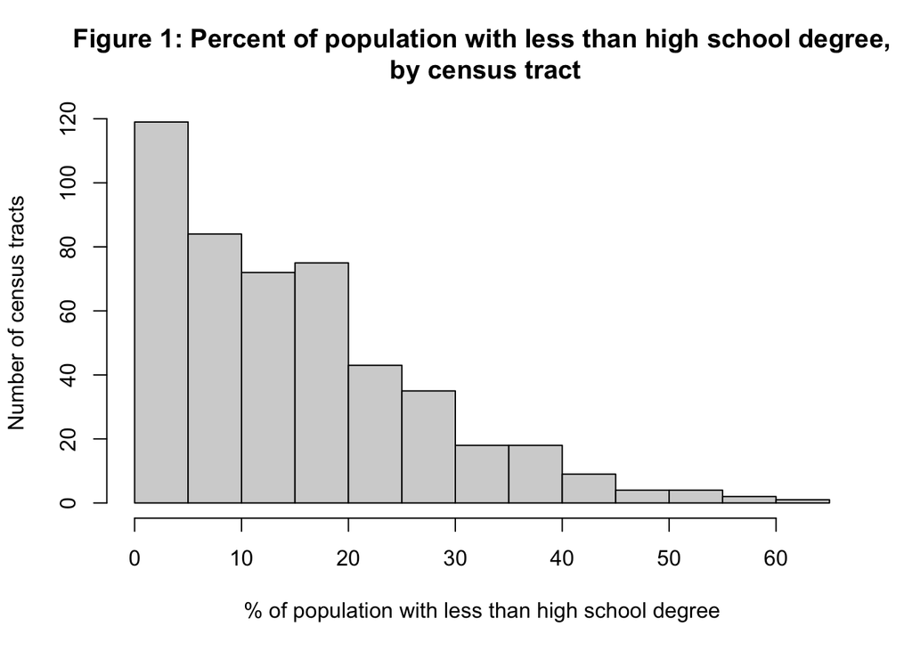

```r
# Read in shapefile of West Virginia census tracts
geospatial_data <- st_read("cb_2022_54_tract_500k", quiet = TRUE)

# Create and display a histogram showing the number of census tracts that have different percentages of population with less than high school education

hist(ed_census_inc_percent_tract$less_than_hs_percent,
     xlab = "% of population with less than high school degree",
     ylab = "Number of census tracts",
     main = "Figure 1: Percent of population with less than high school degree,\n by census tract")
```

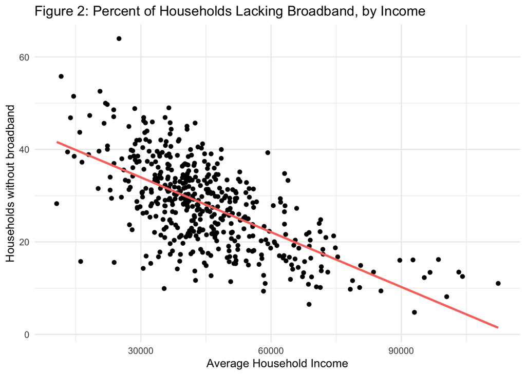

```r
# Create object filtered to census tract names and borders
geospatial_data<- geospatial_data %>%
  select(GEOID, geometry)

# Create data object that only contains the broadband percentage and the census tract identifiers with the "1400000US" (West Virginia) prefix removed
broadband_tract <- ed_census_inc_percent_tract %>%
  select(percent_broadband, GEOID)%>%
  mutate(GEOID = sub("1400000US","",GEOID))

# Join that object to the geometry file and save the result to join_data
join_data <- left_join(x= geospatial_data, broadband_tract, by = "GEOID")

# Filter main data object down to the target values, and remove the West Virginia prefix from the census tract identifiers, and assign to hs_tract
hs_tract <- ed_census_inc_percent_tract %>%
  select(less_than_hs_percent, GEOID, hs_percent, some_college_percent, bachelors_percent)%>%
  mutate(GEOID = sub("1400000US","",GEOID))

# Join hs_tract with the geometry file
join_data2 <- left_join(x= geospatial_data, hs_tract, by = "GEOID")

# Convert income values from characters to numeric values
ed_census_inc_percent_tract$income <- as.numeric(ed_census_inc_percent_tract$income)

# Convert percent broadband values from characters to numeric values
ed_census_inc_percent_tract$percent_broadband <- as.numeric(ed_census_inc_percent_tract$percent_broadband)

# Generate ggplot scatterplot of percent broadband against income
plot1 <- ggplot(data = ed_census_inc_percent_tract,
  aes(x =  income, y= percent_broadband))+
  geom_point()+
  labs(title = "Figure 2: Percent of Households Lacking Broadband, by Income", x ="Average Household Income", y = "Households without broadband")+
  geom_smooth(aes(color = "red"), method = "lm",se = FALSE)+
  theme_minimal()+
  theme(legend.position = "none")

# Display plot
plot1
```

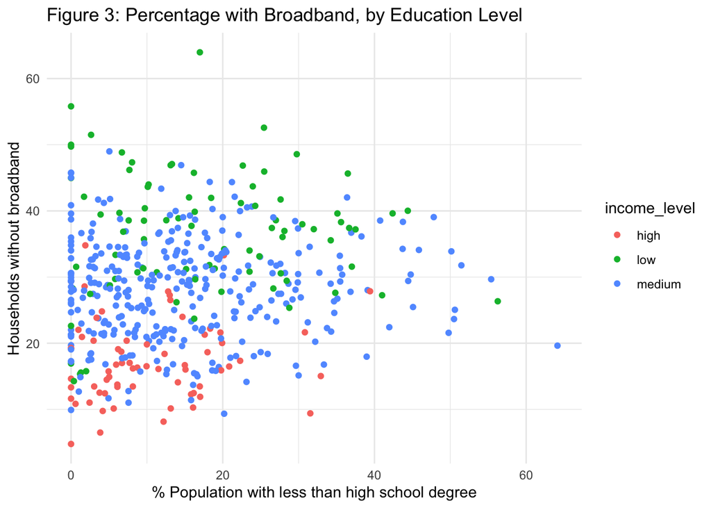

```r
# Assign each census tract an income level of "low," "medium," or "high"
# Low:    < $30,000
# Medium: $30,000 - $60,000
# High:   > $60,000
# Note: Category cutoffs are chosen based on rough distribution of values by census tract in the "income" scatterplot; divides into rough thirds
ed_with_income_lvl <- ed_census_inc_percent_tract %>%
  mutate(income_level = ifelse(income < 33000, "low", ifelse(income >= 33000 & income < 60000,"medium","high"))) %>%
  filter(!is.na(income_level))

# Generate a ggplot scatterplot of percent broadband against percent of residents with less than high school education, with dots colored by income level
plot2 <- ggplot(data = ed_with_income_lvl,
  aes(x =  less_than_hs_percent, y = percent_broadband, color = income_level)) +
  geom_point() +
  labs(title = "Figure 3: Percentage with Broadband, by Education Level", x ="% Population with less than high school degree", y = "Households without broadband")+
  theme_minimal()

# Display plot
plot2
```

## Geospatial Analysis

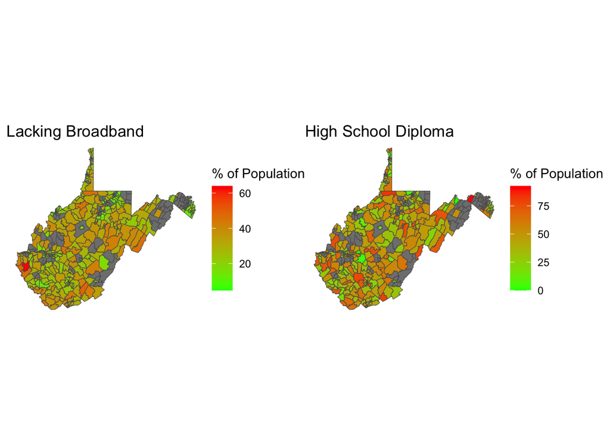

```r
# Create a plot of West Virginia census tracts, using a red-green choropleth to indicate the percentage of population lacking broadband
broadband_plot <- ggplot(st_as_sf(join_data)) +
  geom_sf(aes(fill = percent_broadband)) +
  scale_fill_gradient(high = "red", low = "green") +
  coord_sf()+
  labs(title = "Lacking Broadband")+
  labs(fill = "% of Population")+
  theme_void()

# Create a plot of West Virginia census tracts, using a red-green choropleth to indicate the percentage of population with a high school diploma
ed_plot <- ggplot(st_as_sf(join_data2)) +
  geom_sf(aes(fill = hs_percent)) +
  scale_fill_gradient(high = "red", low = "green") +
  coord_sf()+
  labs(title = "High School Diploma")+
  labs(fill = "% of Population")+
  theme_void()

# Create an object that combines the two plots
plot_together = broadband_plot + ed_plot

# Display combined plot
plot_together
```

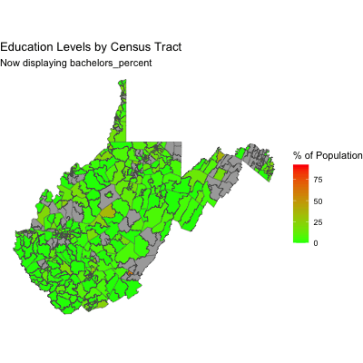

```r
# Pivot dataset into a "long" table, containing the various education values as labels in a column titled "education_level"
hs_tract_long <- tidyr::pivot_longer(
  hs_tract,
  cols = c("less_than_hs_percent", "hs_percent", "some_college_percent", "bachelors_percent"),
  names_to = "education_level",
  values_to = "percentage"
)

# Convert percentages from characters to numeric values
hs_tract_long <- hs_tract_long %>%
    mutate(percentage = as.numeric(percentage))

# Join long table with geometry data by census tract
join_data3 <- left_join(x= hs_tract_long, geospatial_data, by = "GEOID")

# Create an object with geometry and census tract ID
dropped_data <- anti_join(geospatial_data, join_data3, by = "GEOID")

# Create factor from the education_level column
join_data3$education_level <- as.factor(join_data3$education_level)

# Create a "base" plot that can be used to generate multiple visualizations
base_plot <- ggplot(st_as_sf(join_data3)) +
  geom_sf(data = st_as_sf(dropped_data), fill = "darkgrey")+
  geom_sf(aes(fill = percentage)) +
  scale_fill_gradient(high = "red", low = "green") +
  coord_sf()+
  labs(title = "Education Levels by Census Tract")+
  labs(fill = "% of Population")+
  theme_void()

# Create code to create separate visualizations for each kind of education, using the base_plot code
level_plot <- base_plot +
  transition_manual(
    education_level,
    states = unique(join_data3$education_level),
    transition_length = 1,
    state_length = 1
    ) +
  labs(subtitle = "Now displaying {current_frame}")+
  enter_fade() +
  exit_fade()

# Use gifski to create a looping animation of the various education visualizations
animate(
  level_plot,
  duration = 30,
  fps = 20,
  width = 400,
  height = 400,
  renderer = gifski_renderer()
)
```

## Supervised Machine Learning Model

```r
# Set a seed for the random number generator to make use of
set.seed(20201007)

# Remove NA values from income
ml1 <- ed_census_inc_percent_tract%>%
  filter(!(is.na(as.numeric(income))))

# Convert numerical values that are stored as characters
ml1 <-ml1 %>%
  mutate(income = as.numeric(income))%>%
  mutate(income_moe = as.numeric(income_moe))%>%
  mutate(Pop_18.24_MoE = as.numeric(Pop_18.24_MoE))%>%
  select(-GEOID)%>%
  select(-Geographic.Area.Name) %>%
  select(where(is.numeric))

# create a split object
data_split <- initial_split(data = ml1, prop = 0.75)

# create the training and testing data
data_train1 <- training(x = data_split)
data_test1 <- testing(x = data_split)

#Create recipe and use step_normalize on the data
ed_percent_rec <- recipe(percent_broadband ~ .,
                         data = data_train1) %>%
  step_normalize(less_than_hs_percent)

# Prep the recipe
prep_rec <-prep(ed_percent_rec)

# Use "bake" on test and train data to create "processed" test and training objects
data_train_processed <- bake(prep_rec, new_data = data_train1)
data_test_processed <- bake(prep_rec, new_data = data_test1)

# Specify generalized linear model and regression
ed_model <- linear_reg() %>%
  set_engine("glm")%>%
  set_mode(mode = "regression")

# Create workflow
ed_wf <- workflow() %>%
  add_recipe(ed_percent_rec) %>%
  add_model(ed_model)

# Fit the data, using the training data
ed_fit <- ed_wf %>%
  fit(data = data_train1)

# Fit the data, using the processed training data
ed_fit <- ed_wf %>%
  fit(data = data_train_processed)

# Predict the outcomes using the test data and bind the resulting predicted values to the test data
predictions <- bind_cols(
  data_test1,
  predict(object = ed_fit, new_data = data_test1)
)

# Renaming .pred for Windows computers (appears to show as .pred for Windows and .pred_res for Mac computers)

if (".pred" %in% colnames(predictions)) {
  predictions <- predictions %>%
    mutate(.pred_res = .pred)
}



# Create predictions1 object
predictions1 <- predictions %>%
  select(percent_broadband, .pred_res)

# Calculate root mean square error
rmse <- predictions %>%
  yardstick::rmse(truth = percent_broadband, estimate = .pred_res)

# Display RMSE
print(rmse)
```

```
# A tibble: 1 × 3
  .metric .estimator .estimate
  <chr>   <chr>          <dbl>
1 rmse    standard        15.7
```

```r
# Calculate mean absolute error
mae <- predictions %>%
  yardstick::mae(truth = percent_broadband, estimate = .pred_res)

#Print MAE
print(mae)
```

```
# A tibble: 1 × 3
  .metric .estimator .estimate
  <chr>   <chr>          <dbl>
1 mae     standard        12.2
```

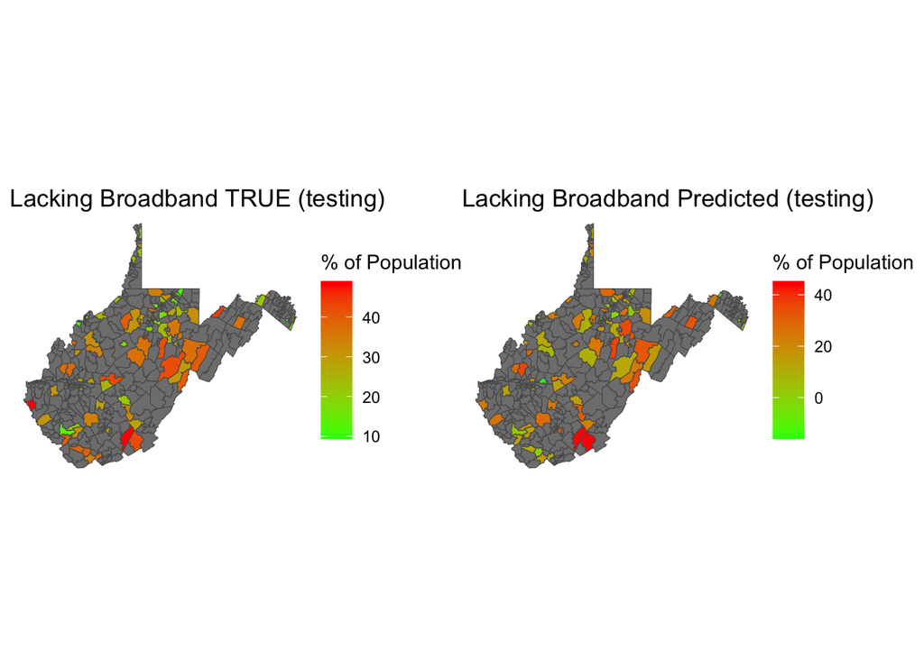

```r
# Join predicted values for percent_broadband from model back into the original dataframe, using the actual value for percent_broadband as the key
predictions_map <- left_join(predictions1, ed_census_inc_percent_tract, by = "percent_broadband")

# Create new predictions_map dataframe with predicted and actual values for percent_broadband, as well as modifying census tract values to drop the prefix
predictions_map <- predictions_map %>%
  select(percent_broadband, .pred_res, GEOID)%>%
  mutate(GEOID = sub("1400000US","",GEOID))

# Join predictions_map dataframe with the geometry dataframe, using census tract as the key
predictions_joined <- left_join(x= geospatial_data, predictions_map, by = "GEOID")

# Create choropleth of actual values of percent of households with broadband
true_values <- ggplot(st_as_sf(predictions_joined)) +
  geom_sf(aes(fill = percent_broadband)) +
  scale_fill_gradient(high = "red", low = "green") +
  coord_sf()+
  labs(title = "Lacking Broadband TRUE (testing)")+
  labs(fill = "% of Population")+
  theme_void()

# Create choropleth of predicted values of percent of households with broadband
predicted_values <- ggplot(st_as_sf(predictions_joined)) +
  geom_sf(aes(fill = .pred_res)) +
  scale_fill_gradient(high = "red", low = "green") +
  coord_sf()+
  labs(title = "Lacking Broadband Predicted (testing)")+
  labs(fill = "% of Population")+
  theme_void()

# Create side-by-side display of the two choropleths
true_v_pred <- true_values + predicted_values

# Display graphics together
true_v_pred
```

## Apply Supervised Machine Learning Results

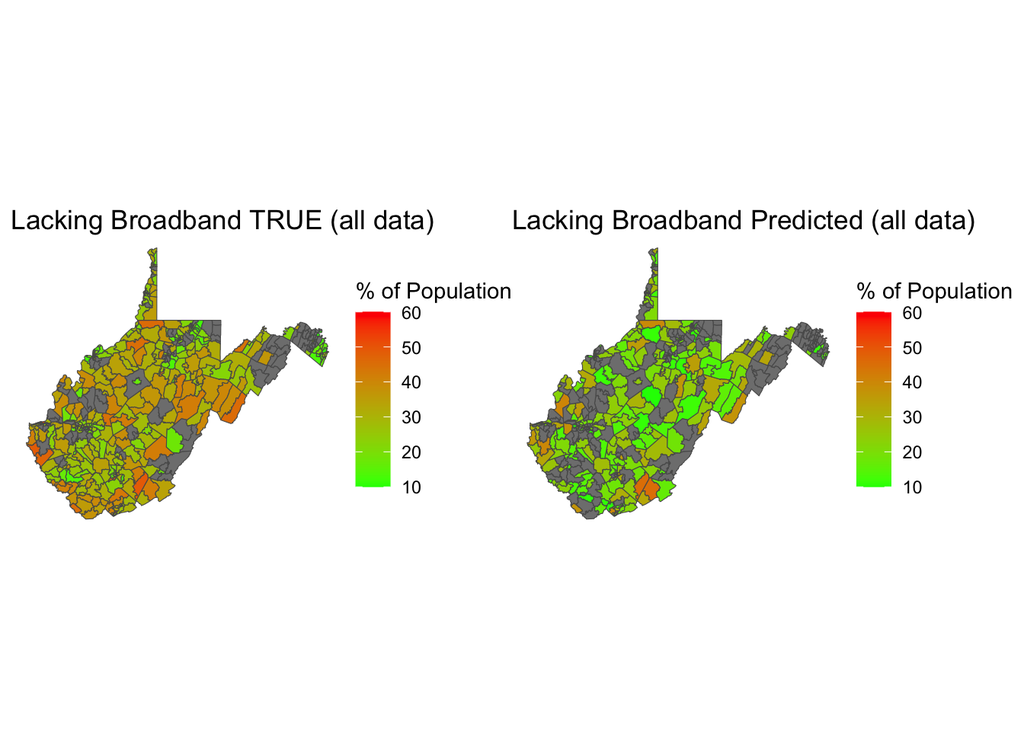

```r
# Create new prediction
predictions_whole <- bind_cols(
  ml1,
  predict(object = ed_fit, new_data = ml1)
)

# Renaming .pred for Windows computers (appears to show as .pred for Windows and .pred_res for Mac computers)

if (".pred" %in% colnames(predictions_whole)) {
  predictions_whole <- predictions_whole %>%
    mutate(.pred_res = .pred)
}


# From prediction output, create predictions2, keeping only the predicted and actual percent broadband
predictions2<- predictions_whole %>%
  select(percent_broadband, .pred_res)

# Join predictions2 back to the original dataset, using the real percent broadband as the key
predictions_map_whole <- left_join(predictions2, ed_census_inc_percent_tract, by = "percent_broadband")

# Modify census tract values to drop the prefix
predictions_map_whole <- predictions_map_whole %>%
  select(percent_broadband, .pred_res, GEOID)%>%
  mutate(GEOID = sub("1400000US","",GEOID))

# Join predictions_map dataframe with the geometry dataframe, using census tract as the key
predictions_joined2 <- left_join(x= geospatial_data, predictions_map_whole, by = "GEOID")

# Create choropleth of true values of percent of households with broadband
true_values_all <- ggplot(st_as_sf(predictions_joined2)) +
  geom_sf(aes(fill = percent_broadband)) +
  scale_fill_gradient(high = "red", low = "green",
                      breaks = c(10,20, 30, 40, 50, 60),
                      limits = c(10, 60)) +
  coord_sf()+
  labs(title = "Lacking Broadband TRUE (all data)")+
  labs(fill = "% of Population")+
  theme_void()

# Create choropleth of predicted values of percent of households with broadband
predicted_values_all <- ggplot(st_as_sf(predictions_joined2)) +
  geom_sf(aes(fill = .pred_res)) +
  scale_fill_gradient(high = "red", low = "green",
                      breaks = c(10,20, 30, 40, 50, 60),
                      limits = c(10, 60)) +
  coord_sf()+
  labs(title = "Lacking Broadband Predicted (all data)")+
  labs(fill = "% of Population")+
  theme_void()

# Create side-by-side display of the two choropleths
true_v_pred2 <- true_values_all + predicted_values_all

# Display graphics together
true_v_pred2
```

## Discussion of Results

Our analysis of the intersection of broadband access and educational outcomes in West Virginia is naturally limited by many factors, but we can draw some preliminary conclusions from our results.

As the rotating education graphic demonstrates, there is considerable consistency in terms of education by census tract, i.e. that places with higher levels of one kind of education tend to have higher levels of other kinds of education. This is reasonable when we consider that geographic measures of income are often strongly correlated with education levels.

The machine learning model accepts as input the numeric values of the dataset, and attempts to calculate the percentage of households that have lack broadband internet access in that census tract. The types of variables used are related to income, education, and a couple of demographic values (population, count of households, population aged 18-24). This is a very basic model, and it does not capture things such as whether a census tract is in an urban or rural area, or whether a tract is in an area where residents can make a good living without high school education (e.g., an area where coal mining is still viable). Another potential limitation is that our model attempts to connect high school education with broadband access, and it is possible that this causal relationship requires more time to develop, and so would be more noticeable in 10-20 years.

The side-by-side maps of the predicted and actual broadband values across the state may look somewhat similar, but a mathematical analysis reveals some problems. As our model uses linear regression to make its predictions, we calculate the root mean square error (RMSE) and mean absolute error (MAE) to evaluate its effectiveness. Since both values are relatively large compared to the size of the data that they are predicting, we can conclude that the model is not doing a particularly great job at predicting broadband access.

Our project set out to examine the links between educational attainment and broadband connectivity. While our estimation may not be able to predict one from the other, it is possible that a different specification or a model with different kinds of data would be better suited for the task. Regardless, given the importance of broadband connectivity to modern education, this remains a policy issue that should be investigated further.